```r
setwd("D:/TA Introducing the data Science/2023 notes/Topic-7")#set the current working directory
getwd()   #get the current working directory
```

```
## [1] "D:/TA Introducing the data Science/2023 notes/Topic-7"
```

# Reading the olivetrain and olivetest datasets

```r
Q4train=read.table("olivetrain.csv",sep = ",",header = T)
Q4test=read.table("olivetest.csv",sep = ",",header = T)
head(Q4train)
```

```
##   macro.area       region palmitic palmitoleic stearic oleic linoleic linolenic
## 1      South Apulia.north     1075          75     226  7823      672        36
## 2      South Apulia.north     1088          73     224  7709      781        31
## 3      South Apulia.north      911          54     246  8113      549        31
## 4      South Apulia.north      966          57     240  7952      619        50
## 5      South Apulia.north     1051          67     259  7771      672        50
## 6      South Apulia.north      911          49     268  7924      678        51
##   arachidic eicosenoic
## 1        60         29
## 2        61         29
## 3        63         29
## 4        78         35
## 5        80         46
## 6        70         44
```

```r
head(Q4test)
```

```
##   macro.area          region palmitic palmitoleic stearic oleic linoleic
## 1   Sardinia Sardinia.inland     1103         109     220  7335     1140
## 2   Sardinia Sardinia.inland     1145          35     237  7208     1118
## 3      South    Apulia.south     1638         252     215  6570     1199
## 4      South    Apulia.south     1518         198     225  6681     1243
## 5      South    Apulia.south     1334         186     229  7261      827
## 6   Sardinia  Sardinia.coast     1076          77     202  7243     1305
##   linolenic arachidic eicosenoic
## 1        28        59          2
## 2        20        46          2
## 3        39        53         29
## 4        29        57         24
## 5        34        56         20
## 6        29        67          1
```

```r
# Finding the unique value in the dataset
unique(Q4train$macro.area)
```

```
## [1] "South"        "Sardinia"     "Centre.North"
```

```r
# Finding NA or missing vales in the dataset
is.na(Q4train$macro.area)
```

[output not shown]

[output cut: 25 more lines]

```r
#Finding missing values of both dataset togther
for(i in 1:10)
{
Q4train<-Q4train[!is.na(Q4train[,i]),]
Q4test<-Q4test[!is.na(Q4test[,i]),]
}
head(Q4train)
```

```
##   macro.area       region palmitic palmitoleic stearic oleic linoleic linolenic
## 1      South Apulia.north     1075          75     226  7823      672        36
## 2      South Apulia.north     1088          73     224  7709      781        31
## 3      South Apulia.north      911          54     246  8113      549        31
## 4      South Apulia.north      966          57     240  7952      619        50
## 5      South Apulia.north     1051          67     259  7771      672        50
## 6      South Apulia.north      911          49     268  7924      678        51
##   arachidic eicosenoic
## 1        60         29
## 2        61         29
## 3        63         29
## 4        78         35
## 5        80         46
## 6        70         44
```

```r
head(Q4test)
```

```
##   macro.area          region palmitic palmitoleic stearic oleic linoleic
## 1   Sardinia Sardinia.inland     1103         109     220  7335     1140
## 2   Sardinia Sardinia.inland     1145          35     237  7208     1118
## 3      South    Apulia.south     1638         252     215  6570     1199
## 4      South    Apulia.south     1518         198     225  6681     1243
## 5      South    Apulia.south     1334         186     229  7261      827
## 6   Sardinia  Sardinia.coast     1076          77     202  7243     1305
##   linolenic arachidic eicosenoic
## 1        28        59          2
## 2        20        46          2
## 3        39        53         29
## 4        29        57         24
## 5        34        56         20
## 6        29        67          1
```

```r
str(Q4train)
```

```
## 'data.frame':    472 obs. of  10 variables:
##  $ macro.area : chr  "South" "South" "South" "South" ...
##  $ region     : chr  "Apulia.north" "Apulia.north" "Apulia.north" "Apulia.north" ...
##  $ palmitic   : int  1075 1088 911 966 1051 911 922 1100 1082 1037 ...
##  $ palmitoleic: int  75 73 54 57 67 49 66 61 60 55 ...
##  $ stearic    : int  226 224 246 240 259 268 264 235 239 213 ...
##  $ oleic      : int  7823 7709 8113 7952 7771 7924 7990 7728 7745 7944 ...
##  $ linoleic   : int  672 781 549 619 672 678 618 734 709 633 ...
##  $ linolenic  : int  36 31 31 50 50 51 49 39 46 26 ...
##  $ arachidic  : int  60 61 63 78 80 70 56 64 83 52 ...
##  $ eicosenoic : int  29 29 29 35 46 44 29 35 33 30 ...
```

```r
str(Q4test)
```

```
## 'data.frame':    100 obs. of  10 variables:
##  $ macro.area : chr  "Sardinia" "Sardinia" "South" "South" ...
##  $ region     : chr  "Sardinia.inland" "Sardinia.inland" "Apulia.south" "Apulia.south" ...
##  $ palmitic   : int  1103 1145 1638 1518 1334 1076 1010 1170 1075 1283 ...
##  $ palmitoleic: int  109 35 252 198 186 77 90 100 91 153 ...
##  $ stearic    : int  220 237 215 225 229 202 350 280 200 196 ...
##  $ oleic      : int  7335 7208 6570 6681 7261 7243 7480 7710 7410 7107 ...
##  $ linoleic   : int  1140 1118 1199 1243 827 1305 1050 640 1107 1115 ...
##  $ linolenic  : int  28 20 39 29 34 29 10 20 36 37 ...
##  $ arachidic  : int  59 46 53 57 56 67 10 70 80 60 ...
##  $ eicosenoic : int  2 2 29 24 20 1 1 3 1 28 ...
```

#Table function (table())in R performs a tabulation of categorical variable and gives its frequency as output.

```r
unique(Q4train$macro.area)
```

```
## [1] "South"        "Sardinia"     "Centre.North"
```

```r
table(Q4train$macro.area)
```

```
##
## Centre.North     Sardinia        South
##          119           80          273
```

```r
table(Q4train$region)
```

```
##
##    Apulia.north    Apulia.south        Calabria    Liguria.east    Liguria.west
##              24             171              46              40              41
##  Sardinia.coast Sardinia.inland          Sicily          Umbria
##              26              54              32              38
```

**LDA (Linear Discriminant Analysis)** :-is a dimensionality reduction technique.

-Linear Discriminant Analysis (LDA) is a supervised learning algorithm used for classification tasks in machine learning. It is a technique used to find a linear combination of features that best separates the classes in a dataset.

-LDA or Linear Discriminant Analysis can be computed in R using the lda() function of the package MASS. -The prior:- argument sets the prior probabilities of class membership. If unspecified, the class proportions for the training set are used.

```r
#https://stats.stackexchange.com/questions/95247/logistic-regression-vs-lda-as-two-class-classifiers
#https://www.geeksforgeeks.org/ml-linear-discriminant-analysis/
## LDA for region
#Package
library(MASS)
unique(Q4train$region)
```

```
## [1] "Apulia.north"    "Calabria"        "Apulia.south"    "Sicily"
## [5] "Sardinia.inland" "Sardinia.coast"  "Umbria"          "Liguria.east"
## [9] "Liguria.west"
```

```r
#model
lda_model <- lda(region~palmitic+palmitoleic+stearic+oleic+linoleic+linolenic+arachidic+eicosenoic,prior = c(1,1,1,1,1,1,1,1,1)/9,data = Q4train)
lda_model
```

```
## Call:
## lda(region ~ palmitic + palmitoleic + stearic + oleic + linoleic +
##     linolenic + arachidic + eicosenoic, data = Q4train, prior = c(1,
##     1, 1, 1, 1, 1, 1, 1, 1)/9)
##
## Prior probabilities of groups:
##    Apulia.north    Apulia.south        Calabria    Liguria.east    Liguria.west
##       0.1111111       0.1111111       0.1111111       0.1111111       0.1111111
##  Sardinia.coast Sardinia.inland          Sicily          Umbria
##       0.1111111       0.1111111       0.1111111       0.1111111
##
## Group means:
##                 palmitic palmitoleic  stearic    oleic  linoleic linolenic
## Apulia.north    1016.542    61.29167 236.0833 7840.250  695.3750 42.458333
## Apulia.south    1398.415   184.61988 210.2222 6904.240 1171.2339 34.824561
## Calabria        1297.413   121.82609 259.1957 7315.326  817.0000 45.130435
## Liguria.east    1163.750    83.75000 240.7500 7720.250  692.7500 28.500000
## Liguria.west    1057.317   111.21951 253.4146 7674.878  893.9024  4.634146
## Sardinia.coast  1139.346   102.03846 243.3462 7080.308 1340.3462 23.769231
## Sardinia.inland 1098.852    96.00000 217.1296 7360.630 1124.7593 28.870370
## Sicily          1230.562   105.40625 271.0938 7339.469  853.8438 42.187500
## Umbria          1086.000    60.78947 193.3421 7954.500  596.1842 34.394737
##                 arachidic eicosenoic
## Apulia.north    72.041667  34.833333
## Apulia.south    60.058480  24.298246
## Calabria        64.173913  28.869565
## Liguria.east    66.000000   1.900000
## Liguria.west     7.317073   2.048780
## Sardinia.coast  73.269231   1.923077
## Sardinia.inland 74.537037   1.944444
## Sicily          75.406250  38.250000
## Umbria          44.157895   1.868421
##
## Coefficients of linear discriminants:
##                      LD1          LD2          LD3         LD4          LD5
## palmitic     0.004779161 -0.003130933  0.001504934  0.01542177 -0.011713141
## palmitoleic  0.006786701 -0.013846003  0.025602455  0.01636167 -0.023678567
## stearic      0.015331122 -0.008567198  0.005243675  0.03248802  0.015220779
## oleic        0.007566074 -0.003860907  0.002602168  0.02153546 -0.016174817
## linoleic     0.014164494 -0.012557613  0.002138050  0.02107735 -0.017128494
## linolenic   -0.049043353  0.003409694 -0.005781536 -0.05156040 -0.058710652
## arachidic    0.032789942 -0.006547179 -0.070652442  0.03592013  0.001300742
## eicosenoic  -0.122519532 -0.123264514  0.028770099  0.09771249 -0.045425213
##                       LD6          LD7          LD8
## palmitic    -0.0390233554  0.006015727  0.032336438
## palmitoleic -0.0530174428 -0.033855356  0.001077971
## stearic     -0.0398457555 -0.016870526  0.034055783
## oleic       -0.0358116054 -0.002338785  0.025664074
## linoleic    -0.0313265047 -0.001611326  0.027481545
## linolenic    0.0003823222 -0.088848322  0.088866303
## arachidic   -0.0702191030  0.003326577 -0.011439963
## eicosenoic  -0.0318883512  0.044044409  0.021460933
##
## Proportion of trace:
##    LD1    LD2    LD3    LD4    LD5    LD6    LD7    LD8
## 0.4415 0.3090 0.1272 0.0692 0.0313 0.0197 0.0012 0.0009
```

*Group means:* These display the mean values for each predictor variable for each region.

*Coefficients of linear discriminants:* These display the linear combination of predictor variables that are used to form the decision rule of the LDA model.For example LD1: 0.004779161*palmitic + 0.006786701*palmitoleic + 0.015331122*stearic …..

*Proportion of trace:* These display the percentage separation achieved by each linear discriminant function.

#assess the accuracy of the prediction using the independent testing set (olivetest)

```r
#The Predict:-It returns the classification and the posterior probabilities of the new data based on the Linear Discriminant model.
##Predict categor
lda_result <- predict(lda_model,Q4test[,3:10])$class

#Confusion matrix
ans <- lda_result == Q4test$region
test_result_lda <- length(which(ans == TRUE))/nrow(Q4test)
cat("Confusion table of LDA:")
```

```
## Confusion table of LDA:
```

```r
result=table(lda_result,Q4test[,2]);result
```

```
##
## lda_result        Apulia.north Apulia.south Calabria Liguria.east Liguria.west
##   Apulia.north               0            0        0            0            0
##   Apulia.south               0           34        0            0            0
##   Calabria                   0            1       10            0            0
##   Liguria.east               0            0        0            7            0
##   Liguria.west               0            0        0            2            9
##   Sardinia.coast             0            0        0            0            0
##   Sardinia.inland            0            0        0            0            0
##   Sicily                     1            0        0            0            0
##   Umbria                     0            0        0            1            0
##
## lda_result        Sardinia.coast Sardinia.inland Sicily Umbria
##   Apulia.north                 0               0      0      0
##   Apulia.south                 0               0      0      0
##   Calabria                     0               0      0      0
##   Liguria.east                 0               0      0      0
##   Liguria.west                 0               0      0      0
##   Sardinia.coast               7               0      0      0
##   Sardinia.inland              0              11      0      0
##   Sicily                       0               0      4      0
##   Umbria                       0               0      0     13
```

```r
# Total percent correct from the testing set
accuracy=sum(diag(result))/100;accuracy
```

```
## [1] 0.95
```

The accuracy of predicting the region is 95%

## LDA for macro.area

```r
unique(Q4train$macro.area)
```

```
## [1] "South"        "Sardinia"     "Centre.North"
```

```r
lda_model <- lda(macro.area~palmitic+palmitoleic+stearic+oleic+linoleic+linolenic+arachidic+eicosenoic,prior = c(1,1,1)/3,data = Q4train)
lda_model
```

```
## Call:
## lda(macro.area ~ palmitic + palmitoleic + stearic + oleic + linoleic +
##     linolenic + arachidic + eicosenoic, data = Q4train, prior = c(1,
##     1, 1)/3)
##
## Prior probabilities of groups:
## Centre.North     Sardinia        South
##    0.3333333    0.3333333    0.3333333
##
## Group means:
##              palmitic palmitoleic  stearic    oleic  linoleic linolenic
## Centre.North 1102.252    85.88235 229.9748 7779.420  731.2185  22.15966
## Sardinia     1112.013    97.96250 225.6500 7269.525 1194.8250  27.21250
## South        1328.150   153.91209 227.8828 7106.810 1032.5092  38.09524
##              arachidic eicosenoic
## Centre.North  38.80672   1.941176
## Sardinia      74.12500   1.937500
## South         63.60440  27.630037
##
## Coefficients of linear discriminants:
##                      LD1          LD2
## palmitic     0.004975500  0.009006987
## palmitoleic  0.015268024  0.014352462
## stearic     -0.003178251  0.005160649
## oleic        0.002366516  0.006184116
## linoleic     0.001586577 -0.001353526
## linolenic    0.047132205  0.001468128
## arachidic   -0.025728260 -0.032161513
## eicosenoic   0.164301603 -0.020680823
##
## Proportion of trace:
##    LD1    LD2
## 0.6756 0.3244
```

```r
#assess the accuracy of the prediction using the independent testing set (olivetest)
lda_result <- predict(lda_model,Q4test[,3:10])$class
```

```r
ans <- lda_result == Q4test$macro.area
test_result_lda <- length(which(ans == TRUE))/nrow(Q4test)
cat("Confusion table of LDA:")
```

```
## Confusion table of LDA:
```

```r
result=table(lda_result,Q4test[,1]);result
```

```
##
## lda_result     Centre.North Sardinia South
##   Centre.North           32        0     1
##   Sardinia                0       18     0
##   South                   0        0    49
```

```r
# Total percent correct from the testing set
accuracy=sum(diag(result))/100;accuracy
```

```
## [1] 0.99
```

The accuracy of predicting macro.area is 99%，Because the group is small, the accuracy rate is higher.。

**Quadratic Discriminant Analysis (QDA)**

-QDA is generally preferred to LDA in the following situations:

1. The training set is large.
2. It’s unlikely that the K classes share a common covariance matrix.

-QDA is implemented in R using the qda() function, which is also part of the MASS library.

#### QDA for region

```r
#https://medium.com/analytics-vidhya/machine-learning-for-classification-quadratic-discriminant-analysis-vs-logistic-regression-582dd748fe03
#model
qda_model <- qda(region~palmitic+palmitoleic+stearic+oleic+linoleic+linolenic+arachidic+eicosenoic,prior = c(1,1,1,1,1,1,1,1,1)/9,data = Q4train)
qda_model
```

```
## Call:
## qda(region ~ palmitic + palmitoleic + stearic + oleic + linoleic +
##     linolenic + arachidic + eicosenoic, data = Q4train, prior = c(1,
##     1, 1, 1, 1, 1, 1, 1, 1)/9)
##
## Prior probabilities of groups:
##    Apulia.north    Apulia.south        Calabria    Liguria.east    Liguria.west
##       0.1111111       0.1111111       0.1111111       0.1111111       0.1111111
##  Sardinia.coast Sardinia.inland          Sicily          Umbria
##       0.1111111       0.1111111       0.1111111       0.1111111
##
## Group means:
##                 palmitic palmitoleic  stearic    oleic  linoleic linolenic
## Apulia.north    1016.542    61.29167 236.0833 7840.250  695.3750 42.458333
## Apulia.south    1398.415   184.61988 210.2222 6904.240 1171.2339 34.824561
## Calabria        1297.413   121.82609 259.1957 7315.326  817.0000 45.130435
## Liguria.east    1163.750    83.75000 240.7500 7720.250  692.7500 28.500000
## Liguria.west    1057.317   111.21951 253.4146 7674.878  893.9024  4.634146
## Sardinia.coast  1139.346   102.03846 243.3462 7080.308 1340.3462 23.769231
## Sardinia.inland 1098.852    96.00000 217.1296 7360.630 1124.7593 28.870370
## Sicily          1230.562   105.40625 271.0938 7339.469  853.8438 42.187500
## Umbria          1086.000    60.78947 193.3421 7954.500  596.1842 34.394737
##                 arachidic eicosenoic
## Apulia.north    72.041667  34.833333
## Apulia.south    60.058480  24.298246
## Calabria        64.173913  28.869565
## Liguria.east    66.000000   1.900000
## Liguria.west     7.317073   2.048780
## Sardinia.coast  73.269231   1.923077
## Sardinia.inland 74.537037   1.944444
## Sicily          75.406250  38.250000
## Umbria          44.157895   1.868421
```

#Predicting the Qda using the test data

```r
########Predict categor
qda_result <- predict(qda_model,Q4test[,3:10])$class
##############confusion matrix
ans <- qda_result == Q4test$region
test_result_qda <- length(which(ans == TRUE))/nrow(Q4test)
cat("Confusion table of QDA:")
```

```
## Confusion table of QDA:
```

```r
result=table(qda_result,Q4test[,2]);result
```

```
##
## qda_result        Apulia.north Apulia.south Calabria Liguria.east Liguria.west
##   Apulia.north               0            0        0            0            0
##   Apulia.south               0           34        0            0            0
##   Calabria                   0            1       10            0            0
##   Liguria.east               0            0        0            9            0
##   Liguria.west               0            0        0            1            9
##   Sardinia.coast             0            0        0            0            0
##   Sardinia.inland            0            0        0            0            0
##   Sicily                     1            0        0            0            0
##   Umbria                     0            0        0            0            0
##
## qda_result        Sardinia.coast Sardinia.inland Sicily Umbria
##   Apulia.north                 0               0      0      0
##   Apulia.south                 0               0      0      0
##   Calabria                     0               0      0      0
##   Liguria.east                 0               0      0      0
##   Liguria.west                 0               0      0      0
##   Sardinia.coast               7               0      0      0
##   Sardinia.inland              0              11      0      0
##   Sicily                       0               0      4      0
##   Umbria                       0               0      0     13
```

```r
###Accuracy
# Total percent correct from the testing set
accuracy=sum(diag(result))/100;accuracy
```

```
## [1] 0.97
```

-The accuracy of predicting the region is 97%。

#### QDA for dependable macro.area

```r
qda_model <- qda(macro.area~palmitic+palmitoleic+stearic+oleic+linoleic+linolenic+arachidic+eicosenoic,prior = c(1,1,1)/3, data = Q4train)
qda_model
```

```
## Call:
## qda(macro.area ~ palmitic + palmitoleic + stearic + oleic + linoleic +
##     linolenic + arachidic + eicosenoic, data = Q4train, prior = c(1,
##     1, 1)/3)
##
## Prior probabilities of groups:
## Centre.North     Sardinia        South
##    0.3333333    0.3333333    0.3333333
##
## Group means:
##              palmitic palmitoleic  stearic    oleic  linoleic linolenic
## Centre.North 1102.252    85.88235 229.9748 7779.420  731.2185  22.15966
## Sardinia     1112.013    97.96250 225.6500 7269.525 1194.8250  27.21250
## South        1328.150   153.91209 227.8828 7106.810 1032.5092  38.09524
##              arachidic eicosenoic
## Centre.North  38.80672   1.941176
## Sardinia      74.12500   1.937500
## South         63.60440  27.630037
```

#Predicting the Qda using the test data

```r
qda_result <- predict(qda_model,Q4test[,3:10])$class
ans <- qda_result == Q4test$macro.area
test_result_qda <- length(which(ans == TRUE))/nrow(Q4test)
cat("Confusion table of QDA:")
```

```
## Confusion table of QDA:
```

```r
result=table(qda_result,Q4test[,1]);result
```

```
##
## qda_result     Centre.North Sardinia South
##   Centre.North           32        0     0
##   Sardinia                0       18     0
##   South                   0        0    50
```

```r
# Total percent correct from the testing set
accuracy=sum(diag(result))/100;accuracy
```

```
## [1] 1
```

-The accuracy of predicting macro.area is 100%，Because the group is small, the accuracy rate is higher.

**Multinomial Logistic Regression:-**

-is used when the target variable is categorical with more than two levels. It is an extension of binomial logistic regression.

-As part of data preparation, ensure that data is free of multicollinearity, outliers, and high influential leverage points.

```r
train=read.table("olivetrain.csv",sep = ",",header = T)
test=read.table("olivetest.csv",sep = ",",header = T)
str(train)
```

```
## 'data.frame':    472 obs. of  10 variables:
##  $ macro.area : chr  "South" "South" "South" "South" ...
##  $ region     : chr  "Apulia.north" "Apulia.north" "Apulia.north" "Apulia.north" ...
##  $ palmitic   : int  1075 1088 911 966 1051 911 922 1100 1082 1037 ...
##  $ palmitoleic: int  75 73 54 57 67 49 66 61 60 55 ...
##  $ stearic    : int  226 224 246 240 259 268 264 235 239 213 ...
##  $ oleic      : int  7823 7709 8113 7952 7771 7924 7990 7728 7745 7944 ...
##  $ linoleic   : int  672 781 549 619 672 678 618 734 709 633 ...
##  $ linolenic  : int  36 31 31 50 50 51 49 39 46 26 ...
##  $ arachidic  : int  60 61 63 78 80 70 56 64 83 52 ...
##  $ eicosenoic : int  29 29 29 35 46 44 29 35 33 30 ...
```

```r
table(train$macro.area)
```

```
##
## Centre.North     Sardinia        South
##          119           80          273
```

```r
xtrain=as.matrix(train[,3:9])
ytrain=as.matrix(train$macro.area)
xtest=as.matrix(test[,3:9])
ytest=as.matrix(test$macro.area)
```

```r
#install.packages('glmnet')
#package
library(glmnet)
#model
mod1 = glmnet(xtrain,ytrain,family="multinomial",lambda=0)
summary(mod1)
```

```
##            Length Class  Mode
## a0         3      -none- numeric
## beta       3      -none- list
## dfmat      3      -none- numeric
## df         1      -none- numeric
## dim        2      -none- numeric
## lambda     1      -none- numeric
## dev.ratio  1      -none- numeric
## nulldev    1      -none- numeric
## npasses    1      -none- numeric
## jerr       1      -none- numeric
## offset     1      -none- logical
## classnames 3      -none- character
## grouped    1      -none- logical
## call       5      -none- call
## nobs       1      -none- numeric
```

```r
coef(mod1)
```

```
## $Centre.North
## 8 x 1 sparse Matrix of class "dgCMatrix"
##                       s0
##             64.881501098
## palmitic     0.088892613
## palmitoleic  0.069499534
## stearic      .
## oleic        .
## linoleic     .
## linolenic    0.009065534
## arachidic    .
##
## $Sardinia
## 8 x 1 sparse Matrix of class "dgCMatrix"
##                        s0
##             -9.433338e+02
## palmitic    -7.041843e-03
## palmitoleic -4.851591e-01
## stearic      8.315186e-02
## oleic        9.615320e-02
## linoleic     3.766243e-01
## linolenic   -6.856557e-01
## arachidic    1.164789e+00
##
## $South
## 8 x 1 sparse Matrix of class "dgCMatrix"
##                       s0
##             878.45231434
## palmitic      .
## palmitoleic   .
## stearic      -0.08226467
## oleic        -0.08257126
## linoleic     -0.06817154
## linolenic     .
## arachidic    -0.04429913
```

```r
#predicting the categoria
prob=predict(mod1,xtest,type="response");prob[1:20,1:3,1]
```

```
##       Centre.North     Sardinia        South
##  [1,] 9.237362e-13 1.000000e+00 3.398881e-11
##  [2,] 2.189365e-16 1.000000e+00 2.500746e-09
##  [3,] 2.924598e-03 8.592523e-77 9.970754e-01
##  [4,] 7.629060e-04 3.906728e-42 9.992371e-01
##  [5,] 1.092422e-02 4.085307e-76 9.890758e-01
##  [6,] 7.772992e-48 1.000000e+00 2.311516e-45
##  [7,] 7.312891e-01 1.053034e-03 2.676578e-01
##  [8,] 9.811840e-01 2.656103e-45 1.881605e-02
##  [9,] 1.744451e-23 1.000000e+00 9.959266e-22
## [10,] 9.812427e-04 1.743343e-26 9.990188e-01
## [11,] 1.133734e-03 1.025798e-74 9.988663e-01
## [12,] 6.510657e-04 4.572045e-38 9.993489e-01
## [13,] 9.532959e-01 1.140023e-47 4.670414e-02
## [14,] 1.238785e-02 2.277108e-46 9.876122e-01
## [15,] 4.529335e-04 6.570098e-24 9.995471e-01
## [16,] 8.002326e-04 5.327614e-31 9.991998e-01
## [17,] 6.695689e-44 1.000000e+00 1.515736e-41
## [18,] 9.851527e-04 5.832326e-31 9.990148e-01
## [19,] 1.422009e-02 6.273112e-19 9.857799e-01
## [20,] 9.421153e-01 5.343479e-10 5.788473e-02
```

```r
label=predict(mod1,xtest,type="class");label[1:20,]
```

```
##  [1] "Sardinia"     "Sardinia"     "South"        "South"        "South"
##  [6] "Sardinia"     "Centre.North" "Centre.North" "Sardinia"     "South"
## [11] "South"        "South"        "Centre.North" "South"        "South"
## [16] "South"        "Sardinia"     "South"        "South"        "Centre.North"
```

```r
#Building classification table
tab=table(predict=label,real=ytest);tab
```

```
##               real
## predict        Centre.North Sardinia South
##   Centre.North           31        0     1
##   Sardinia                0       18     1
##   South                   1        0    48
```

```r
#Accuarcy of the test dataset
sum(diag(tab))/sum(tab)
```

```
## [1] 0.97
```

-Our model accuracy has turned out to be 97% in the testdataset dataset.

**Logistic Regression**

- Logistic regression is used when the dependent variable is binary(0/1, True/False, Yes/No) in nature. The logit function is used as a link function in a binomial distribution.

## Creating the binary dataset for traning

```r
#https://www.geeksforgeeks.org/logistic-regression-in-r-programming/
unique(train$region)
```

```
## [1] "Apulia.north"    "Calabria"        "Apulia.south"    "Sicily"
## [5] "Sardinia.inland" "Sardinia.coast"  "Umbria"          "Liguria.east"
## [9] "Liguria.west"
```

```r
table(train$region)
```

```
##
##    Apulia.north    Apulia.south        Calabria    Liguria.east    Liguria.west
##              24             171              46              40              41
##  Sardinia.coast Sardinia.inland          Sicily          Umbria
##              26              54              32              38
```

```r
Calabria=which(train$region=='Calabria')
Sicily=which(train$region=='Sicily')
xytrain=data.frame(train[c(Calabria,Sicily),2:9])
xytrain
```

```
##       region palmitic palmitoleic stearic oleic linoleic linolenic arachidic
## 25  Calabria     1315         139     230  7299      832        42        60
## 26  Calabria     1321         136     217  7174      950        43        63
## 27  Calabria     1359         115     246  7234      874        45        63
## 28  Calabria     1378         111     272  7127      940        46        64
## 29  Calabria     1295         109     245  7253      903        43        62
## 30  Calabria     1275         121     215  7285      892        40        68
## 31  Calabria     1336         120     318  7083      915        50        70
## 32  Calabria     1309         122     241  7257      870        46        72
## 33  Calabria     1340         114     189  7337      820        48        72
## 34  Calabria     1299         116     253  7309      823        40        69
## 35  Calabria     1221         107     221  7441      798        54        70
## 36  Calabria     1245          72     283  7395      829        44        67
## 37  Calabria     1285         129     244  7323      819        57        65
## 38  Calabria     1248         107     313  7299      840        46        66
```

[output cut: 64 more lines]

## Creating the binary dataset for testing.

```r
Calabria=which(test$region=='Calabria')
Sicily=which(test$region=='Sicily')
xytest=data.frame(test[c(Calabria,Sicily),2:9])
xytest
```

```
##      region palmitic palmitoleic stearic oleic linoleic linolenic arachidic
## 11 Calabria     1366         147     291  7197      783        51        70
## 34 Calabria     1287         108     287  7343      826        44        44
## 44 Calabria     1255         103     223  7395      848        47        56
## 46 Calabria     1383         118     273  7282      738        45        68
## 55 Calabria     1298          99     311  7311      787        45        67
## 63 Calabria     1432         152     281  7029      949        39        55
## 72 Calabria     1336         113     242  7293      855        38        60
## 76 Calabria     1267         101     300  7230      898        74        65
## 86 Calabria     1359          98     351  7262      780        41        56
## 97 Calabria     1261         153     219  7355      818        52        70
## 12   Sicily     1404         134     210  7110      923        40       101
## 14   Sicily     1222         133     227  7425      824        36        69
## 21   Sicily     1105          69     373  7714      532        51        68
## 38   Sicily     1112          68     375  7770      448        52        69
```

```r
xytrain$region=as.factor(xytrain$region)
xytrain$region
```

```
##  [1] Calabria Calabria Calabria Calabria Calabria Calabria Calabria Calabria
##  [9] Calabria Calabria Calabria Calabria Calabria Calabria Calabria Calabria
## [17] Calabria Calabria Calabria Calabria Calabria Calabria Calabria Calabria
## [25] Calabria Calabria Calabria Calabria Calabria Calabria Calabria Calabria
## [33] Calabria Calabria Calabria Calabria Calabria Calabria Calabria Calabria
## [41] Calabria Calabria Calabria Calabria Calabria Calabria Sicily   Sicily
## [49] Sicily   Sicily   Sicily   Sicily   Sicily   Sicily   Sicily   Sicily
## [57] Sicily   Sicily   Sicily   Sicily   Sicily   Sicily   Sicily   Sicily
## [65] Sicily   Sicily   Sicily   Sicily   Sicily   Sicily   Sicily   Sicily
## [73] Sicily   Sicily   Sicily   Sicily   Sicily   Sicily
## Levels: Calabria Sicily
```

```r
#model
mod2<-glm(formula=region~.,data=xytrain,family=binomial(link="logit"))
summary(mod2)
```

```
##
## Call:
## glm(formula = region ~ ., family = binomial(link = "logit"),
##     data = xytrain)
##
## Deviance Residuals:
##      Min        1Q    Median        3Q       Max
## -2.15895  -0.07807  -0.00675   0.04868   2.05375
##
## Coefficients:
##               Estimate Std. Error z value Pr(>|z|)
## (Intercept) -439.49436  381.51703  -1.152  0.24934
## palmitic       0.01817    0.03515   0.517  0.60514
## palmitoleic    0.03275    0.06082   0.538  0.59026
## stearic        0.10328    0.05432   1.901  0.05726 .
## oleic          0.04363    0.03807   1.146  0.25185
## linoleic       0.04366    0.03874   1.127  0.25978
## linolenic     -0.61739    0.24958  -2.474  0.01337 *
## arachidic      0.80315    0.27408   2.930  0.00339 **
## ---
## Signif. codes:  0 '***' 0.001 '**' 0.01 '*' 0.05 '.' 0.1 ' ' 1
##
## (Dispersion parameter for binomial family taken to be 1)
##
##     Null deviance: 105.604  on 77  degrees of freedom
## Residual deviance:  22.122  on 70  degrees of freedom
## AIC: 38.122
##
## Number of Fisher Scoring iterations: 8
```

*Significance codes:* The level of significance of each predictor variable is indicated by the significance codes.

*Dispersion parameter:* In logistic regression, the dispersion parameter serves as the scaling parameter for the binomial distribution. It is set to 1 in this instance, indicating that the assumed dispersion is 1.

*Null deviance:* The null deviance calculates the model’s deviation when just the intercept is taken into account. It symbolizes the deviation that would result from a model with no predictors.

*Residual deviance:* The residual deviance calculates the model’s deviation after the predictors have been fitted. It stands for the residual deviation after taking the predictors into account.

*AIC: The Akaike Information Criterion (AIC)*, which accounts for the number of predictors, is a gauge of a model’s goodness of fit. It penalizes more intricate models in order to prevent overfitting. Better-fitting models are indicated by lower AIC values.

*Number of Fisher Scoring iterations:* The number of iterations needed by the Fisher scoring procedure to estimate the model parameters is indicated by the number of iterations.

```r
##predicting the model using test dataset
prob=predict(mod2,xytest,type="response");prob
```

```
##           11           34           44           46           55           63
## 1.005499e-03 1.083444e-08 4.208267e-07 3.836086e-03 2.314008e-01 1.248265e-05
##           72           76           86           97           12           14
## 1.843214e-03 7.340573e-10 8.148195e-03 2.623823e-04 1.000000e+00 9.736080e-01
##           21           38
## 9.860755e-01 9.713219e-01
```

```r
label=rep('',length(prob))
label[prob<0.5]='Calabria'
label[prob>=0.5]='Sicily'
label
```

```
##  [1] "Calabria" "Calabria" "Calabria" "Calabria" "Calabria" "Calabria"
##  [7] "Calabria" "Calabria" "Calabria" "Calabria" "Sicily"   "Sicily"
## [13] "Sicily"   "Sicily"
```

```r
xytest$region=as.character(xytest$region)
##Confusion table
tab=table(predict=label,real=xytest$region);tab
```

```
##           real
## predict    Calabria Sicily
##   Calabria       10      0
##   Sicily          0      4
```

```r
## Accuracy
sum(diag(tab))/sum(tab)
```

```
## [1] 1
```

-Our model accuracy has turned out to be 100%

**Naive Bayes**

-Naive Bayes is a statistical classification technique based on Bayes Theorem. It is one of the simplest supervised learning algorithms.

-Naive Bayes classifier assumes that the effect of a particular feature in a class is independent of other features.

```r
set=iris[iris$Species=='setosa',]
ver=iris[iris$Species=='versicolor',]
vir=iris[iris$Species=='virginica',]
s=sample(1:50,40)
xytrain=rbind(set[s,],ver[s,],vir[s,])
xytest=rbind(set[-s,],ver[-s,],vir[-s,])
```

```r
#install.packages('e1071')
library(e1071)
## model
NBclass=naiveBayes(Species~.,data=xytrain)
#prediction
label=predict(NBclass,xytest)
###Confusion table
tab=table(predict=label,real=xytest$Species);tab
```

```
##             real
## predict      setosa versicolor virginica
##   setosa         10          0         0
##   versicolor      0          8         0
##   virginica       0          2        10
```

```r
##Accuracy
sum(diag(tab))/sum(tab)
```

```
## [1] 0.9333333
```

#ROC(receiver operating characteristic curve)

```r
#install.packages('PRROC')
library(PRROC)
credit = read.csv('Credit.csv')
table(credit$Married)
```

```
##
##  No Yes
## 155 245
```

```r
credit$Married = as.factor(credit$Married)
mod3<-glm(formula=Married~Income+Limit+Rating+Cards+Age+Education+Balance,data=credit,family=binomial(link="logit"))
prob=predict(mod3,credit,type="response");prob
```

[output not shown]

[output cut: 45 more lines]

[output not shown]

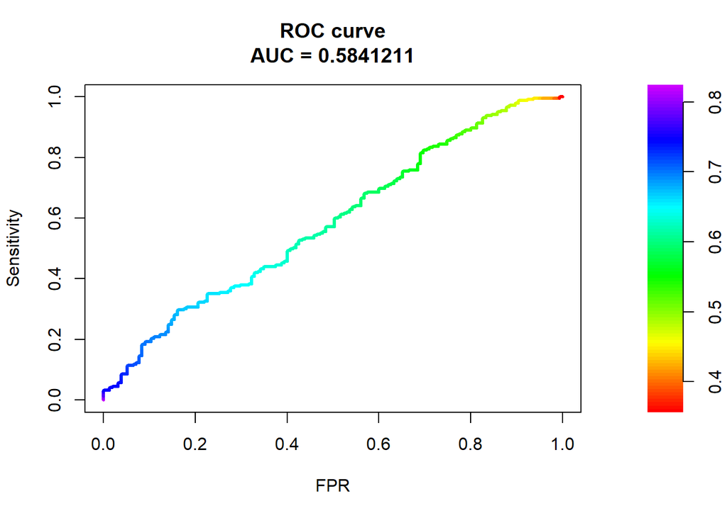

```r
PRROC_obj=roc.curve(scores.class0=prob,weights.class0=as.numeric(as.factor(credit$Married))-1,curve=TRUE)
plot(PRROC_obj)
```

#LDA Visualize

```r
xy=rbind(train,test)
xy=xy[,-2]
LDA=lda(macro.area~.,data=xy)
pre=data.frame(predict(LDA)$x)
pre$class=predict(LDA)$class
table(xy$macro.area)
```

```
##
## Centre.North     Sardinia        South
##          151           98          323
```

```r
setc=c(mean(pre$LD1[pre$class=='Centre.North']),mean(pre$LD2[pre$class=='Centre.North']))
verc=c(mean(pre$LD1[pre$class=='Sardinia']),mean(pre$LD2[pre$class=='Sardinia']))
virc=c(mean(pre$LD1[pre$class=='South']),mean(pre$LD2[pre$class=='South']))
mu=data.frame(LD1=c(setc[1],verc[1],virc[1]),LD2=c(setc[2],verc[2],virc[2]))
mu$class=c('Centre.North','Sardinia','South')
```

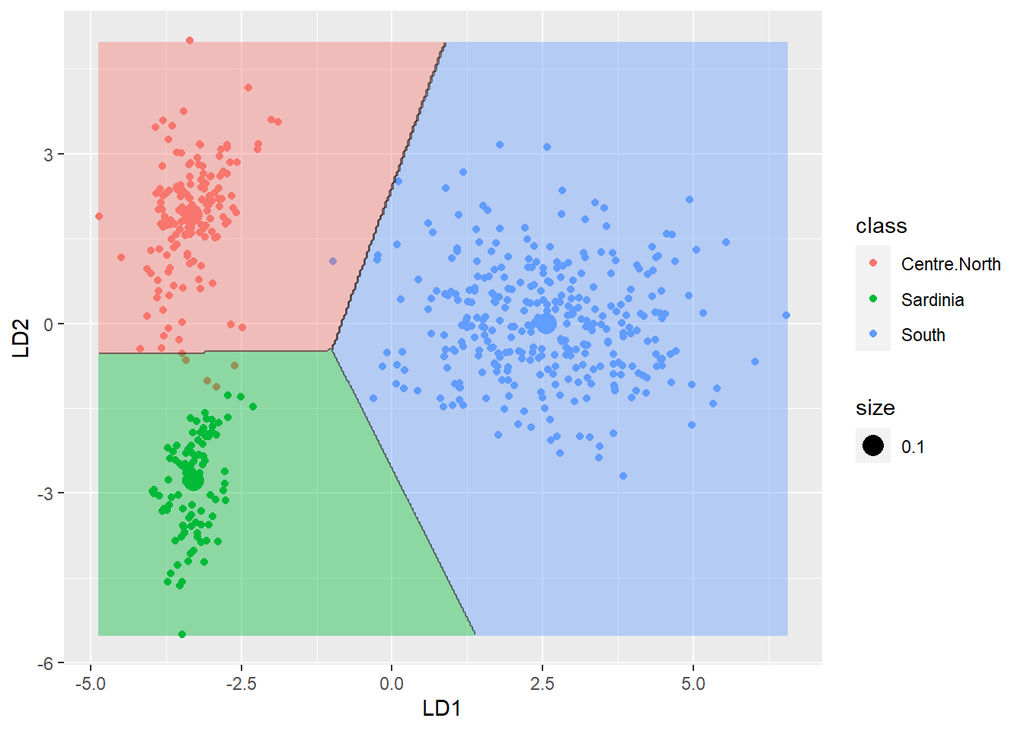

```r
library(ggplot2)
LDA2 <- lda(class ~ LD1 + LD2, data=pre)
ld1lim <- range(c(min(pre$LD1),max(pre$LD1)),mul=0.05)
ld2lim <- range(c(min(pre$LD2),max(pre$LD2)),mul=0.05)
ld1 <- seq(ld1lim[[1]], ld1lim[[2]], length.out=300)
ld2 <- seq(ld2lim[[1]], ld1lim[[2]], length.out=300)
newdat <- expand.grid(list(LD1=ld1,LD2=ld2))
preds <-predict(LDA2,newdata=newdat)
predclass <- preds$class
postprob <- preds$posterior
df <- data.frame(x=newdat$LD1, y=newdat$LD2, class=predclass)
df$classnum <- as.numeric(df$class)
df <- cbind(df,postprob)
df=df[-which(df$y>max(pre$LD2)),]
pre$class=xy$macro.area
ggplot(pre, aes(x=LD1, y=LD2, colour=class) ) +
geom_point() +
geom_raster(data=df, aes(x=x, y=y, fill = factor(class)),alpha=0.4,show_guide=FALSE) +
geom_contour(data=df, aes(x=x, y=y, z=classnum), colour="black", alpha=0.5, breaks=c(1.5,2.5)) +
geom_point(data=mu, aes(x=LD1, y=LD2, colour=class,cex=0.1))
```

```r
#install.packages('ellipse')
library(ellipse)
dat_ell=pre
for(g in unique(pre$class))
{
exy=pre[pre$class==g,]
ex=exy$LD1
ey=exy$LD2
ell=ellipse(cor(ex,ey),scale=c(sd(ex),sd(ey)),centre=c(mean(ex),mean(ey)))
ell=cbind(ell,rep(g,dim(exy)[1]))
ell=data.frame(ell)
colnames(ell)=colnames(pre)
dat_ell=rbind(dat_ell,ell)
}
```

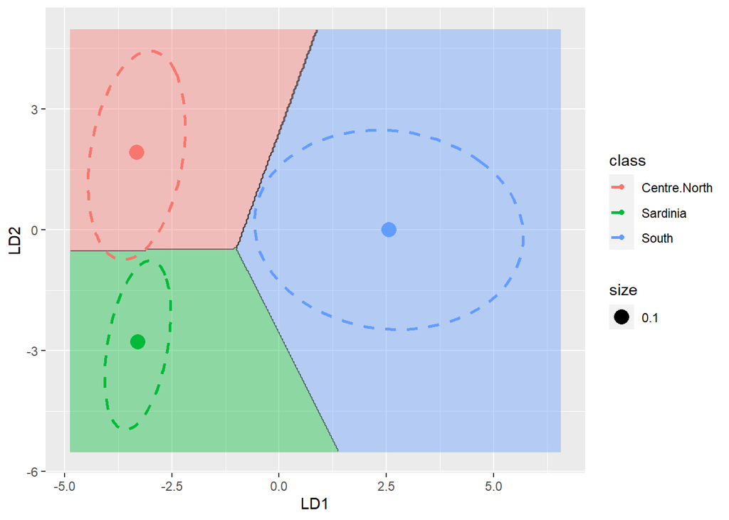

```r
dat_ell=dat_ell[-(1:dim(pre)[1]),]
dat_ell$LD1=as.numeric(dat_ell$LD1)
dat_ell$LD2=as.numeric(dat_ell$LD2)

ggplot(pre, aes(x=LD1, y=LD2, colour=class) ) +
geom_raster(data=df, aes(x=x, y=y, fill = factor(class)),alpha=0.4,show_guide=FALSE) +
geom_contour(data=df, aes(x=x, y=y, z=classnum), colour="black", alpha=0.5, breaks=c(1.5,2.5)) +
geom_point(data=mu, aes(x=LD1, y=LD2, colour=class,cex=0.1)) +
geom_path(data=dat_ell,aes(x=LD1,y=LD2,colour=class),size=1,linetype=2)
```

#LDA Visualize with Iris data

```r
LDA=lda(Species~.,data=iris)
pre=data.frame(predict(LDA)$x)
pre$LD1=-pre$LD1
pre$class=predict(LDA)$class
setc=c(mean(pre$LD1[pre$class=='setosa']),mean(pre$LD2[pre$class=='setosa']))
verc=c(mean(pre$LD1[pre$class=='versicolor']),mean(pre$LD2[pre$class=='versicolor']))
virc=c(mean(pre$LD1[pre$class=='virginica']),mean(pre$LD2[pre$class=='virginica']))
mu=data.frame(LD1=c(setc[1],verc[1],virc[1]),LD2=c(setc[2],verc[2],virc[2]))
mu$class=c('setosa','versicolor','virginica')
```

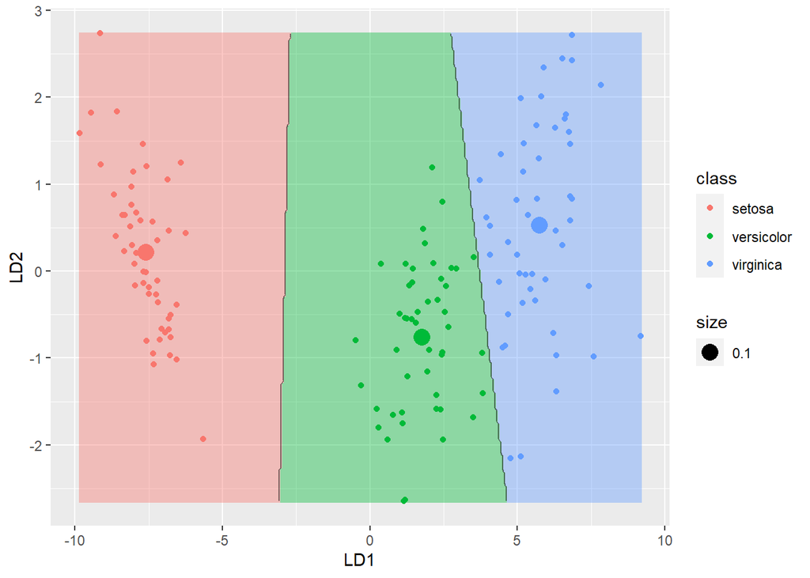

```r
library(ggplot2)
LDA2 <- lda(class ~ LD1 + LD2, data=pre)
ld1lim <- range(c(min(pre$LD1),max(pre$LD1)),mul=0.05)
ld2lim <- range(c(min(pre$LD2),max(pre$LD2)),mul=0.05)
ld1 <- seq(ld1lim[[1]], ld1lim[[2]], length.out=300)
ld2 <- seq(ld2lim[[1]], ld1lim[[2]], length.out=300)
newdat <- expand.grid(list(LD1=ld1,LD2=ld2))
preds <-predict(LDA2,newdata=newdat)
predclass <- preds$class
postprob <- preds$posterior
df <- data.frame(x=newdat$LD1, y=newdat$LD2, class=predclass)
df$classnum <- as.numeric(df$class)
df <- cbind(df,postprob)
df=df[-which(df$y>max(pre$LD2)),]
#$class=iris$Species
ggplot(pre, aes(x=LD1, y=LD2, colour=class) ) +
geom_point() +
geom_raster(data=df, aes(x=x, y=y, fill = factor(class)),alpha=0.4,show_guide=FALSE) +
geom_contour(data=df, aes(x=x, y=y, z=classnum), colour="black", alpha=0.5, breaks=c(1.5,2.5)) +
geom_point(data=mu, aes(x=LD1, y=LD2, colour=class,cex=0.1))
```

#QDA Visualize

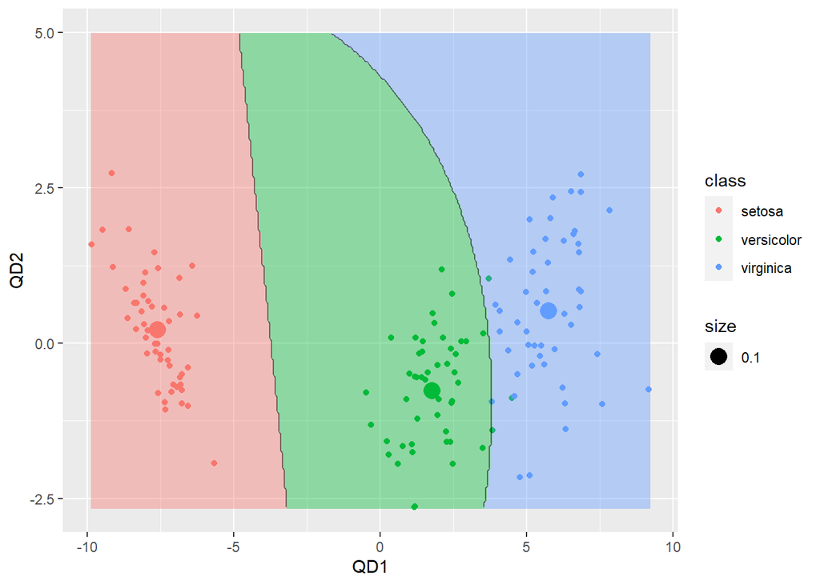

```r
library(ggplot2)
QDA <- qda(class ~ LD1 + LD2, data=pre)
ld1lim <- range(c(min(pre$LD1),max(pre$LD1)),mul=0.05)
ld2lim <- range(c(min(pre$LD2),max(pre$LD2)),mul=0.05)
ld1 <- seq(ld1lim[[1]], ld1lim[[2]], length.out=300)
ld2 <- seq(ld2lim[[1]], ld1lim[[2]], length.out=300)
newdat <- expand.grid(list(LD1=ld1,LD2=ld2))
preds <-predict(QDA,newdata=newdat)
predclass <- preds$class
postprob <- preds$posterior
df <- data.frame(x=newdat$LD1, y=newdat$LD2, class=predclass)
df$classnum <- as.numeric(df$class)
df <- cbind(df,postprob)
df=df[-which(df$y>5),]
pre$class=iris$Species
p=ggplot(pre, aes(x=LD1, y=LD2, colour=class) ) +
geom_point() +
geom_raster(data=df, aes(x=x, y=y, fill = factor(class)),alpha=0.4,show_guide=FALSE) +
geom_contour(data=df, aes(x=x, y=y, z=classnum), colour="black", alpha=0.5, breaks=c(1.5,2.5)) +
geom_point(data=mu, aes(x=LD1, y=LD2, colour=class,cex=0.1))
p+labs(x='QD1',y=('QD2'))
```

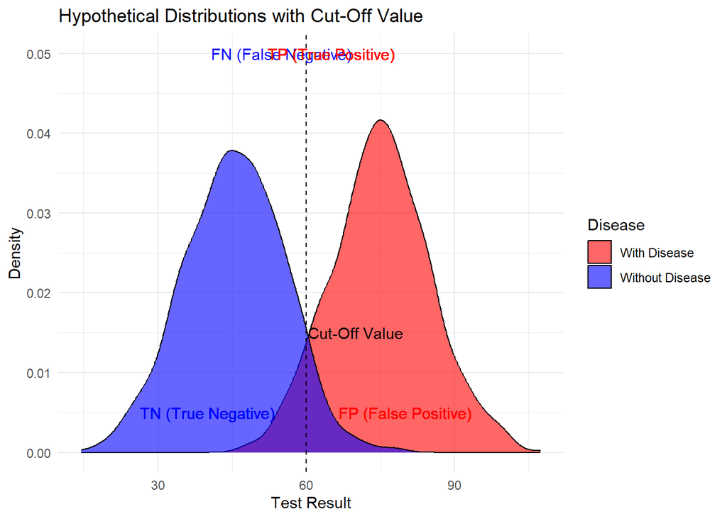

```r
# Load the ggplot2 package
library(ggplot2)

# Create example data for two distributions
set.seed(123)  # for reproducibility
n <- 1000  # Total number of patients

# Generate data for patients with the disease
disease_data <- data.frame(Disease = "With Disease", Test_Result = rnorm(n, mean = 75, sd = 10))

# Generate data for patients without the disease
no_disease_data <- data.frame(Disease = "Without Disease", Test_Result = rnorm(n, mean = 45, sd = 10))

# Combine the data
combined_data <- rbind(disease_data, no_disease_data)

# Set the cut-off value
cut_off <- 60

# Create a ggplot2 plot
ggplot(combined_data, aes(x = Test_Result, fill = Disease)) +
  geom_density(alpha = 0.6) +
  geom_vline(xintercept = cut_off, linetype = "dashed") +
  scale_fill_manual(values = c("With Disease" = "red", "Without Disease" = "blue")) +
  theme_minimal() +
  labs(
    title = "Hypothetical Distributions with Cut-Off Value",
    x = "Test Result",
    y = "Density"
  ) +
  annotate("text", x = cut_off + 10, y = 0.015, label = "Cut-Off Value", color = "black") +
  annotate("text", x = cut_off - 5, y = 0.05, label = "FN (False Negative)", color = "blue") +
  geom_text(aes(x = cut_off - 20, y = 0.005, label = "TN (True Negative)"), color = "blue") +
  geom_text(aes(x = cut_off + 20, y = 0.005, label = "FP (False Positive)"), color = "red") +
  geom_text(aes(x = cut_off + 5, y = 0.05, label = "TP (True Positive)"), color = "red")
```

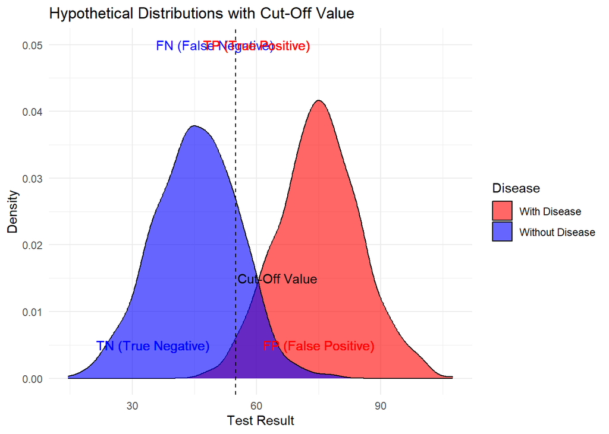

```r
# Load the ggplot2 package
library(ggplot2)

# Create example data for two distributions
set.seed(123)  # for reproducibility
n <- 1000  # Total number of patients

# Generate data for patients with the disease
disease_data <- data.frame(Disease = "With Disease", Test_Result = rnorm(n, mean = 75, sd = 10))

# Generate data for patients without the disease
no_disease_data <- data.frame(Disease = "Without Disease", Test_Result = rnorm(n, mean = 45, sd = 10))

# Combine the data
combined_data <- rbind(disease_data, no_disease_data)

# Set the cut-off value
cut_off <- 55

# Create a ggplot2 plot
ggplot(combined_data, aes(x = Test_Result, fill = Disease)) +
  geom_density(alpha = 0.6) +
  geom_vline(xintercept = cut_off, linetype = "dashed") +
  scale_fill_manual(values = c("With Disease" = "red", "Without Disease" = "blue")) +
  theme_minimal() +
  labs(
    title = "Hypothetical Distributions with Cut-Off Value",
    x = "Test Result",
    y = "Density"
  ) +
  annotate("text", x = cut_off + 10, y = 0.015, label = "Cut-Off Value", color = "black") +
  annotate("text", x = cut_off - 5, y = 0.05, label = "FN (False Negative)", color = "blue") +
  geom_text(aes(x = cut_off - 20, y = 0.005, label = "TN (True Negative)"), color = "blue") +
  geom_text(aes(x = cut_off + 20, y = 0.005, label = "FP (False Positive)"), color = "red") +
  geom_text(aes(x = cut_off + 5, y = 0.05, label = "TP (True Positive)"), color = "red")
```